# Comments by Andrey

# JASS performance on real data from UK Biobank

We compared the performance of two multi-trait GWAS methods, MANOVA and JASS, by conducting analysis on the UK Biobank data [Sudlow2015](https://doi.org/10.1371/journal.pmed.1001779), [Bycroft2017](https://www.biorxiv.org/content/early/2017/07/20/166298). In brief, we selected five anthropometric traits and 619,017 high-quality genotyped SNPs with MAF>1% available in a subset of 336,347 unrelated individuals of the British ancestry. Since MANOVA is designed for association studies without any covariates, we projected out all relevant covariates such as age and gender, 20 principal components estimated on genetic data and the variable of genotyping platform. For MANOVA, we ran its implementation in PLINK [Ferreira2008](https://doi.org/10.1093/bioinformatics/btn563). For JASS, we proceeded in three steps: (1) compute single-trait GWAS for five anthropometric traits and store the summary statistics; (2) estimate the phenotypic correlation matrix by LDSC [Bulik-Sullivan2015](https://doi.org/10.1038/ng.3406); and (3) compute the Omnibus test to get multi-trait statistics. Further details of the analysis are given below.

To evaluate the JASS performance, we focused on the accuracy in estimation of the phenotypic correlation matrix. We first computed the phenotypic correlation matrix by the Pearson correlation (the MANOVA approach) using the raw data, then estimated the same matrix by LDSC (the JASS approach) using summary statistics from single-trait GWAS, and finally derived the relative error of the LDSC estimator in comparison to the Pearson correlation. We also visually assessed the distribution of multi-trait GWAS p-values by a scatterplot between log (base 10) of p-values from MANOVA and JASS.

We repeated the comparative study between MANOVA and JASS several times by varying the level of missing data (artificially introduced). We examined the influence of missing data on the performance of JASS in two regimes. In the first regime, we down-sampled the whole dataset by setting 50%, 90% and 99% of phenotypic data to missing for all five traits; the resulted sample size was 168,173, 33,635 and 3,363 individuals, respectively. In the second regime, we similarly down-sampled the phenotypic data of a single trait at the same rates of 50%, 90% and 99%; that led to different sample overlaps between the down-sampled trait and others.

In the presence of sample overlap between pairs of traits (**Figure 2**), we conclude that JASS performs reasonably well for 100% and 50% sample overlap. Though, the relative errors in estimation phenotypic correlations becomes rather large for smaller sample overlaps of 10% and 1% (relative errors up to 7% and 26%, respectively). These results are consistent with our results obtained on simulated data.

## Figure 1

Figure 1: JASS performance in multi-trait GWAS on 100%, 50%, 10% and 1% UK Biobank sample size.

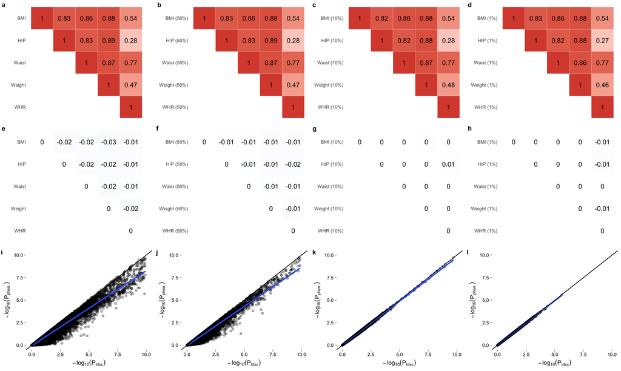

The top raw panel (a-d) shows the Pearson phenotypic correlations estimated on different sample sizes. The middle raw panel (e-h) shows the relative error of LDSC estimator in comparison to the Pearson estimator. Negative values mean underestimation by JASS; zeros mean values below 0.01 (except the diagonal values). The bottom raw panel (i-l) compares the p-values from two Omnibus tests, one based on the Pearson and the other based on LDSC correlations, for multi-trait GWAS conducted on different sample sizes. The test based on the Pearson correlation is equivalent to MANOVA. Large p-values with negative log (base 10) values greater than 10 are not plotted.

## Figure 2

Figure 2: JASS performance in multi-trait GWAS on different sample overlaps 100%, 50%, 10% and 1%.

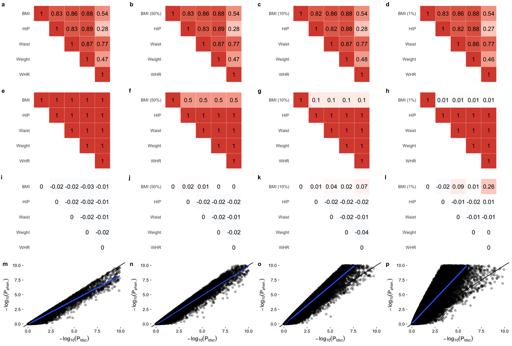

The top raw panel (a-d) shows the Pearson phenotypic correlations estimated for four traits at 100% sample size and BMI at different sample sizes. The upper middle raw panel (e-h) depicts the sample overlap for all pairs of traits. The lower middle raw panel (i-l) shows the relative error of LDSC estimator in comparison to the Pearson estimator. Negative values mean underestimation by JASS; zeros mean values below 0.01 (except the diagonal values). The bottom raw panel (m-p) compares the p-values from two Omnibus tests, one based on the Pearson and the other based on LDSC correlations, for multi-trait GWAS conducted on different sample sizes for BMI. The test based on the Pearson correlation is equivalent to MANOVA. Large p-values with negative log (base 10) values greater than 10 are not plotted.

## Data preparation: traits, covariates, genotypes

Overall, we followed a pipeline on processing UK Biobank data described in [Loh2018](https://doi.org/10.1038/s41588-018-0144-6).

We considered UK Biobank (stringent) British individuals and removed all related individuals, that reduced the sample size from araound 500,000 to 337,536 individuals. Principal components (PCs) were computed on genotyped variants using PLINK2 [Chang2015](https://doi.org/10.1186/s13742-015-0047-8). Additionally, we harmonized the five traits in terms of missing values to have 100% sample sample overlap: we removed individuals with missing values for any of the five traits. The final sample size used in the analysis was 336,347.

We worked only with the genotyped variants (SNPs) and applied the following quality controls: missing rate >0.9; minimum allele frequency >0.01. The final number of SNPs used in the analysis was 619,017.

We selected five anthropometric traits that measure body mass index (BMI), hip (HIP), waist (Waist), weight (Weight), and waist to hip ratio (WHR). We did not included the measurements of height, as its GWAS has been recently found cumbersome in the UK Biobank dataset due to uncorrected population structure [Sohail2018](https://www.biorxiv.org/content/early/2018/07/09/355057).

Before conducting GWAS, we transformed traits to be covariate-free (requirement by the MANOVA approach). The following covariates were projected out: assess center, genotyping array, gender, age, age squared and 20 principal components. We assured that the GWAS results for both modes, covariate-free and covariates included in the model, are almost identical for all five traits (data not shown).

## Multi-trait GWAS by MANOVA

We executed multi-trait GWAS (the MANOVA method) by the extension of PLINK [Ferreira2008](https://doi.org/10.1093/bioinformatics/btn563) (command `plink.multivariate --noweb --allow-no-sex --mqfam --bfile <path_bfile> --mult-pheno <path_phen>`). Since the computation was rather slow for UK Biobank sample size, we switched to the Omnibus test that needs single-trait summary statistics and the Pearson correlation matrix among traits. This Omnibus test is equivalent to MANOVA, that was also confirmed in our UK Biobank analysis for Chromosome 1 at 100% sample size (data not shown).

## Phenotypic bi-variate correlations by LDSC

We followed the standard pipeline in running the LDSC regression [Bulik-Sullivan2015](https://doi.org/10.1038/ng.3406), [Bulik-Sullivan2015-2](https://doi.org/10.1038/ng.3211): munge the input data of summary statistics; build the ld-scores from a reference panel; estimate the heritability in single-trait analysis ($h^2$); estimate the correlation ($\rho$)for pairs of traits in bi-variate analysis.

As data preparation steps, we munge the files of single-trait summary statistics (command `python2 <path_ldsc> --sumstats <path_ss> --N-col <col_n> --a1 <col_a1> --a2 <col_a2> --ignore <col_ignoted> --out <path_out>`) and computed the ld-scores from the 1,000 Genomes reference panel, European super-population, Phase III (command `python2 <path_ldsc> --l2 --bfile <bed_ref_panel_1KG> --ld-wind-cm 1 --out <out_path_ldsc> --print-snps <path_snps_ukbiobank>`).

For estimating the covariance matrix between pairs of Z-scores, e.g. vectors $Z_1$ for trait 1 and $Z_2$ for trait 2, we needed two types of quantities from the LDSC regression: $E[Z_i^2 | l_j]$ [Bulik-Sullivan2015-2](https://doi.org/10.1038/ng.3211) and $E[Z_1 Z_2 | l_j]$ [Bulik-Sullivan2015](https://doi.org/10.1038/ng.3406). More precisely, each of the two quantities has two parts of the linear regression, namely the intercept and the slope (related to the genetic signal). Thus, we extracted the intercept part from each of the two analyses.

For the single-trait analysis, we ran the LDSC regression for every trait (command `python2 <path_ldsc> --h2 <path_ss> --ref-ld-chr <path_ldsc> --w-ld-chr <path_ldsc> --out <out_name>`). Further, we stored the intercept part of $E[Z_i^2 | l_j]$, which is equivalent to $1 + N a$, where $N$ is the sample size and $a$ measures the contribution of confounding biases.

For bi-variate analysis, we executed the LDSC regression for all pairs of traits (command `python2 <path_ldsc> --rg <path_ss_trait_1>,<path_ss_trait_2> --ref-ld-chr <path_ldsc> --w-ld-chr <path_ldsc> --out <out_name>`). Similarly, we stored the intercept part of $E[Z_1 Z_2 | l_j]$, which is equivalent to $\rho N_s / \sqrt{N_1 N_2}$, where $N_i$ is the sample size for trait $i$, $N_s$ is the sample overlap, $\rho$ is the phenotypic correlation in $N_s$ overlapping samples. To extract the $\rho$ value from the analysis, we needed the estimate of intercept and values of $N_1$, $N_2$ and $N_s$.

## Multi-trait GWAS by JASS

We used results from the LDSC regression analysis (the intercept parts) to construct the Omnibus test. Additionally, we scaled the covariance matrix to the correlation matrix (the R function `cov2cor`), as diagonal entries on the LDSC covariance matrix might substantially deviate from 1 especially at 100% UK Biobank sample size (by up to 20%). We found this scaling operation to improve the overall performance of the Omnibus test (data not shown).

## Acknowledgements

This research was conducted using the UK Biobank Resource under Application #16549.